# Data Science Project 2 - `Titanic Survival` Dataset Analysis

## Completed Individually By Anish Deshpande

## Introduction and Problem Scope

The dataset that I decided to analyze for this project is the `Titanic Survival` Dataset. This dataset includes various columns related to all of the titanic passengers that we currently know about when it crashed into the iceberg and was published about 2 years ago. When I saw this, it was immediately something that I was interested in as history is something that fascinates me. The dataset includes passenger numbers, their names, whether they survived the incident, their passenger class, their sex, their age, the number of siblings and spouses that they had on the trip, how many parents and children they had aboard, their ticket number, the fare that they paid for the ticket, the cabin that they stayed in, and where the passenger embarked from (where they boarded from). The questions that I decided to answer mainly focus on how those certain categories effected the survival rate of the passengers, as there might be some correlation between those columns and what happened to the people that were aboard the ship. In other words, which factors that night had a relationship to the survival rate. This will help get us to a better understanding of why certain people survived in comparison to others and further insights on the crash that might have contributed to the casualities that night. This could benefit stake-holders since it will give them intuition in the historical time period in which the event took place, which could improve our historical knowledge. Along with this, it will allow us to compare the norms during that time period to the ones that we hold now, and assess how the event would have played out if it would have taken place during the time that we live in.

## Questions that I Will be Answering

1. What was the true difference between the casualties and the survivors?
2. Were younger passengers (25 or younger) more likely to survive?
3. Did gender affect survival?
4. Did the passenger class affect survival?
5. Was there any relationship between fare price and survival?
6. Did the embarked location matter in survival?
7. Did family size play a role in survival?

## Preprocessing and Cleaning

```python
!pip install pandas
!pip install matplotlib
```

```python
import pandas as pd
import numpy as np
import matplotlib.pyplot as plt
```

This is the first few lines of the raw data. It is difficult to see the missing data from here as they are present further on in the dataset. One thing that I would like to point out is the fact that the column `Cabin` has some missing values. However, since none of my questions revolve around the `Cabin` column, I decided that it is okay for it to remain unchanged.

```python
data = pd.read_csv("titanic.csv")
data.head()
```

|  | PassengerId | Survived | Pclass | Name | Sex | Age | SibSp | Parch | Ticket | Fare | Cabin | Embarked |
| --- | --- | --- | --- | --- | --- | --- | --- | --- | --- | --- | --- | --- |
| 0 | 1 | 0 | 3 | Braund, Mr. Owen Harris | male | 22.0 | 1 | 0 | A/5 21171 | 7.2500 | NaN | S |
| 1 | 2 | 1 | 1 | Cumings, Mrs. John Bradley (Florence Briggs Th... | female | 38.0 | 1 | 0 | PC 17599 | 71.2833 | C85 | C |
| 2 | 3 | 1 | 3 | Heikkinen, Miss Laina | female | 26.0 | 0 | 0 | STON/O2. 3101282 | 7.9250 | NaN | S |
| 3 | 4 | 1 | 1 | Futrelle, Mrs. Jacques Heath (Lily May Peel) | female | 35.0 | 1 | 0 | 113803 | 53.1000 | C123 | S |
| 4 | 5 | 0 | 3 | Allen, Mr. William Henry | male | 35.0 | 0 | 0 | 373450 | 8.0500 | NaN | S |

```python
data.info()
```

```
<class 'pandas.DataFrame'>
RangeIndex: 891 entries, 0 to 890
Data columns (total 12 columns):
 #   Column       Non-Null Count  Dtype
---  ------       --------------  -----
 0   PassengerId  891 non-null    int64
 1   Survived     891 non-null    int64
 2   Pclass       891 non-null    int64
 3   Name         891 non-null    str
 4   Sex          891 non-null    str
 5   Age          714 non-null    float64
 6   SibSp        891 non-null    int64
 7   Parch        891 non-null    int64
 8   Ticket       891 non-null    str
 9   Fare         891 non-null    float64
 10  Cabin        204 non-null    str
 11  Embarked     889 non-null    str
dtypes: float64(2), int64(5), str(5)
memory usage: 83.7 KB
```

For the `Age` column, I decided to fill the missing values using the median value of all ages. This would be the best decision to make as dropping the values completely would result in an immense loss of data and filling it out with some artibtrary number would lead to higher amount of innacurracy. Along with this, the mean would no be a good option here either as mean is a value that is often skewed easily by outliers, unlike the median.

```python
data["Age"] = data["Age"].fillna(data["Age"].median())
```

I decided to use the same procedure on the `Fare` column, as both are numerical data types.

```python
data["Fare"] = data["Fare"].fillna(data["Fare"].median())
```

For the `Embarked` column, I decided to fill the mising values up with the location that was the most common between the passengers, which is "S". In this case, both the median and mean would not make sense as this is a string data type, not a numerical one like integers and floats.

```python
data["Embarked"] = data["Embarked"].fillna("S")
```

Finally, for the final question, I am going to add a column called `Family Size` that will give the number of people in the passengers family. This will include the passenger themselves as well.

```python
data["FamilySize"] = data["SibSp"] + data["Parch"] + 1
```

## Exploratory Data Analysis & Visualization

Now that we are done with preprocessing, we have to take a look at our data and understand what is going on to better get an idea of the people who were on the ship that night. This will give us a good visual of various groups and give us a better representation of the dataset in general.

Since the main problem and the questions that I am looking into mainly revolves around survival, the best thing to take a look at first would be the amount of survivors that there were in comparison to non-survivors. We can do this by getting statistics and graphs on the count of survivors and the proportion of survivors as well.

```
Survival Counts:
Survived
0    549
1    342
dtype: int64

Survival Proportions:
Survived
0    0.616162
1    0.383838
dtype: float64
```

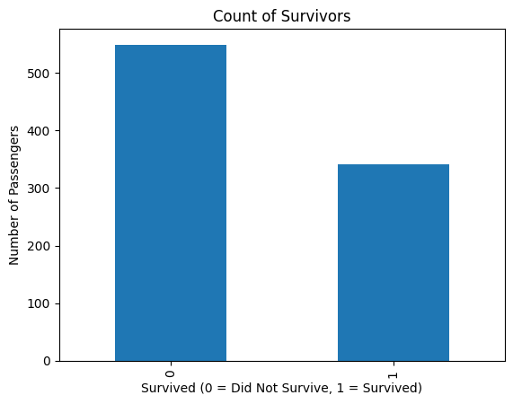

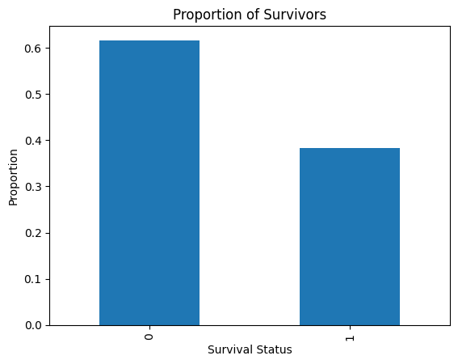

```
Overall Survival Rate:
0.3838383838383838
```

```python
survival_counts = data.groupby("Survived").size()
print("Survival Counts:")
print(survival_counts)
survival_rate = survival_counts / survival_counts.sum()
print("\nSurvival Proportions:")
print(survival_rate)
survival_counts.plot(kind="bar")
plt.title("Count of Survivors")
plt.xlabel("Survived (0 = Did Not Survive, 1 = Survived)")
plt.ylabel("Number of Passengers")
plt.show()
survival_rate.plot(kind="bar")
plt.title("Proportion of Survivors")
plt.xlabel("Survival Status")
plt.ylabel("Proportion")
plt.show()
print("\nOverall Survival Rate:")
print(data["Survived"].mean())
```

As you can see from the survivor count, there were many more that didn't survive than people that did. In fact, the difference is quite drastic at about 200. This helps show that the average survival rate that we will calculate later will most likely be on the lower side. We can also see from the proportion graph that about 60% of the population on that ship were unable to survive, and later on we will find out which factors played an important role in the groups of people that were a part of that percentage.

Along with the number of people that did survive, another good thing that we should take a look at is the relationship between the passengers on board. We can do this by looking at the bar graphs between age, gender, and what class they were a part of.

```
Statistics Related to Age:
count    891.000000
mean      29.361582
std       13.019697
min        0.420000
25%       22.000000
50%       28.000000
75%       35.000000
max       80.000000
Name: Age, dtype: float64

Mean Age: 29.36158249158249
Median Age: 28.0
```

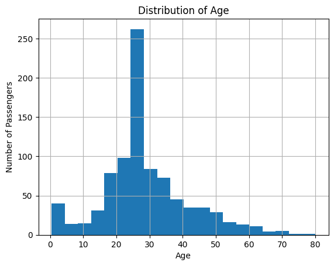

```
Passenger Count by Age Group:
AgeGroup
Adult          241
Child           69
Older Adult     64
Teen            70
Young Adult    447
dtype: int64
```

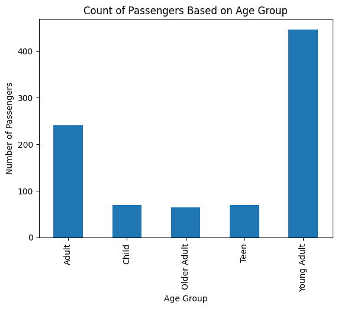

```python
print("Statistics Related to Age:")
print(data["Age"].describe())
mean_age = data["Age"].mean()
median_age = data["Age"].median()
print("\nMean Age:", mean_age)
print("Median Age:", median_age)
data["Age"].hist(bins=20)
plt.title("Distribution of Age")
plt.xlabel("Age")
plt.ylabel("Number of Passengers")
plt.show()
data["AgeGroup"] = "Older Adult"
data.loc[data["Age"] <= 50, "AgeGroup"] = "Adult"
data.loc[data["Age"] <= 30, "AgeGroup"] = "Young Adult"
data.loc[data["Age"] <= 18, "AgeGroup"] = "Teen"
data.loc[data["Age"] <= 12, "AgeGroup"] = "Child"
age_group_counts = data.groupby("AgeGroup").size()
print("\nPassenger Count by Age Group:")
print(age_group_counts)
age_group_counts.plot(kind="bar")
plt.title("Count of Passengers Based on Age Group")
plt.xlabel("Age Group")
plt.ylabel("Number of Passengers")
plt.show()
```

```
Number of Passengers by Sex:
Sex
female    314
male      577
dtype: int64

Proportion of Passengers by Sex:
Sex
female    0.352413
male      0.647587
dtype: float64
```

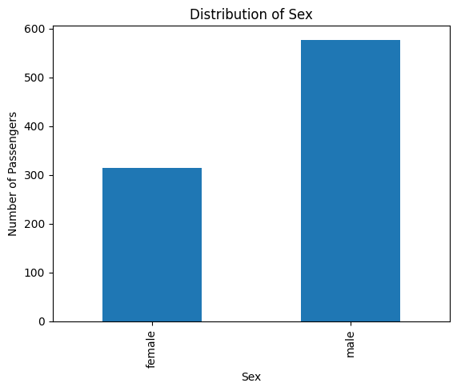

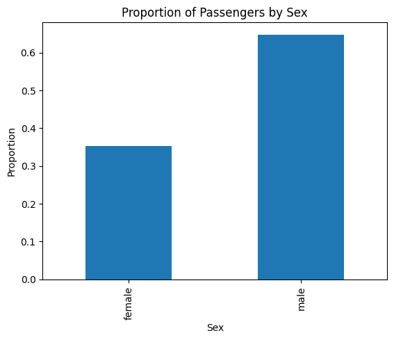

```python
gender_counts = data.groupby("Sex").size()
print("Number of Passengers by Sex:")
print(gender_counts)
gender_proportions = gender_counts / gender_counts.sum()
print("\nProportion of Passengers by Sex:")
print(gender_proportions)
gender_counts.plot(kind="bar")
plt.title("Distribution of Sex")
plt.xlabel("Sex")
plt.ylabel("Number of Passengers")
plt.show()
gender_proportions.plot(kind="bar")
plt.title("Proportion of Passengers by Sex")
plt.xlabel("Sex")
plt.ylabel("Proportion")
plt.show()
```

```
Passenger Count by Class:
Pclass
1    216
2    184
3    491
dtype: int64

Proportion of Passengers by Class:
Pclass
1    0.242424
2    0.206510
3    0.551066
dtype: float64
```

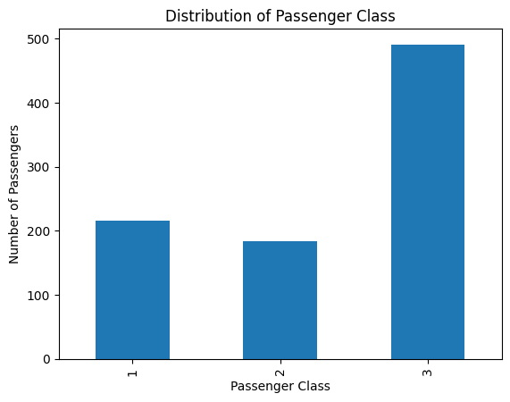

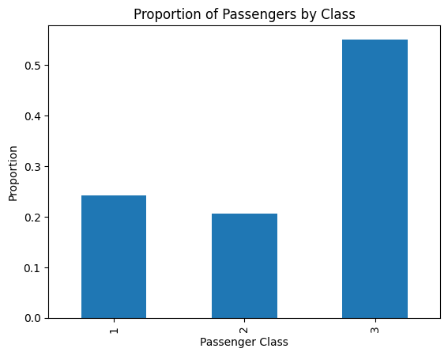

```
Sorted Class Counts:
Pclass
1    216
2    184
3    491
dtype: int64
```

```python
class_counts = data.groupby("Pclass").size()
print("Passenger Count by Class:")
print(class_counts)
class_proportions = class_counts / class_counts.sum()
print("\nProportion of Passengers by Class:")
print(class_proportions)
class_counts.plot(kind="bar")
plt.title("Distribution of Passenger Class")
plt.xlabel("Passenger Class")
plt.ylabel("Number of Passengers")
plt.show()
class_proportions.plot(kind="bar")
plt.title("Proportion of Passengers by Class")
plt.xlabel("Passenger Class")
plt.ylabel("Proportion")
plt.show()
sorted_class_counts = class_counts.sort_index()
print("\nSorted Class Counts:")
print(sorted_class_counts)
```

```
Passenger Count by Embarkation Port:
Embarked
C    168
Q     77
S    646
dtype: int64

Proportion of Passengers by Embarkation Port:
Embarked
C    0.188552
Q    0.086420
S    0.725028
dtype: float64
```

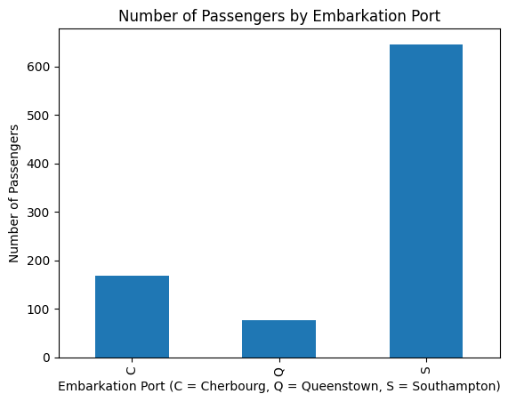

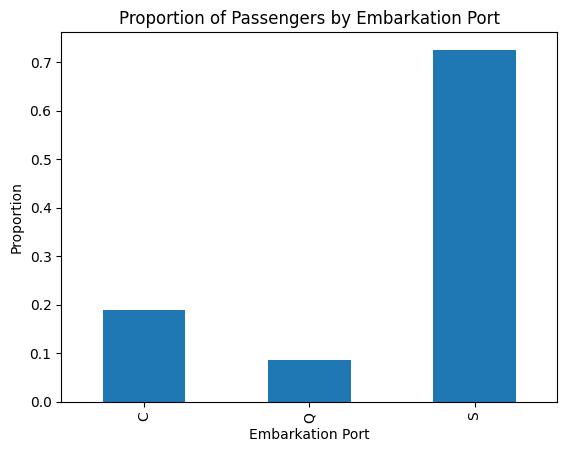

```python
embark_counts = data.groupby("Embarked").size()
print("Passenger Count by Embarkation Port:")
print(embark_counts)
embark_proportions = embark_counts / embark_counts.sum()
print("\nProportion of Passengers by Embarkation Port:")
print(embark_proportions)
embark_counts.plot(kind="bar")
plt.title("Number of Passengers by Embarkation Port")
plt.xlabel("Embarkation Port (C = Cherbourg, Q = Queenstown, S = Southampton)")
plt.ylabel("Number of Passengers")
plt.show()
embark_proportions.plot(kind="bar")
plt.title("Proportion of Passengers by Embarkation Port")
plt.xlabel("Embarkation Port")
plt.ylabel("Proportion")
plt.show()
```

This was super interesting for me to see at the start. After doing some research, I figured out that the Southampton port was actually the main port chosen since it was pretty massive and was home to many huge ships. Along with this, it wss near where many of the first class passengers resided. With this logic, we can also assume that the other two ports were home to a good amount of the lower class passengers.

## Questions and Queries

1. What was the true difference between the casualties and the survivors?

```python
survival_rate = data["Survived"].mean()
death_rate = 1 - survival_rate
difference = death_rate - survival_rate
print("\nDifference between Death and Survival Rates:")
print(difference)
total_passengers = len(data)
print("\nTotal Passengers:", total_passengers)
estimated_survivors = survival_rate * total_passengers
estimated_deaths = death_rate * total_passengers
print("\nEstimated Survivors:", estimated_survivors)
print("Estimated Deaths:", estimated_deaths)
```

```
Difference between Death and Survival Rates:
0.23232323232323232

Total Passengers: 891

Estimated Survivors: 342.0
Estimated Deaths: 549.0
```

2. Were younger passengers (25 or younger) more likely to survive?

```
Difference in Survival Rates (Young - Old): 0.04246860746663661

Number of Young Passengers: 301
Number of Older Passengers: 590
```

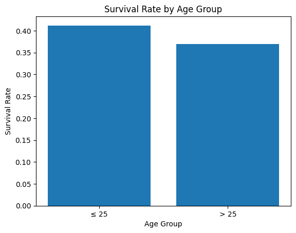

```python
young = data[data["Age"] <= 25]
old = data[data["Age"] > 25]
young_survival_rate = young["Survived"].mean()
old_survival_rate = old["Survived"].mean()
difference = young_survival_rate - old_survival_rate
print("\nDifference in Survival Rates (Young - Old):", difference)
print("\nNumber of Young Passengers:", len(young))
print("Number of Older Passengers:", len(old))
plt.bar(["≤ 25", "> 25"], [young_survival_rate, old_survival_rate])
plt.title("Survival Rate by Age Group")
plt.xlabel("Age Group")
plt.ylabel("Survival Rate")
plt.show()
```

Through this comparison, we can see if there was any correlation between the survivors and age. From these numbers, it seems that people that were on the younger side had a slightly higher advantage. However, this difference is minimal, and it seemed that overall, they roughly found themselves in the same conditions as the people on the older side since the numebr are extremely simiilar. So we can conclude that this didn't have much of an impact on the survival rates of the passengers.

3. Did gender affect survival?

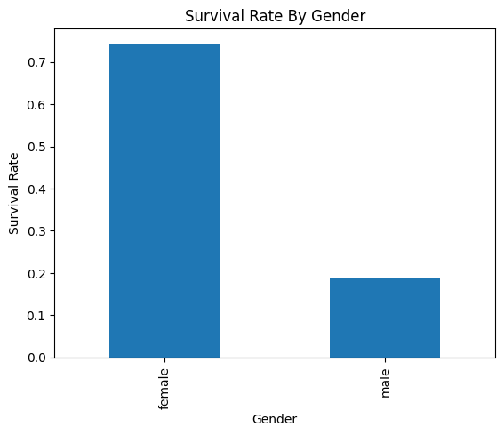

```python
data.groupby("Sex")["Survived"].mean().plot(kind="bar")
plt.title("Survival Rate By Gender")
plt.xlabel("Gender")
plt.ylabel("Survival Rate")
plt.show()
```

If we look at this visual, we can see that there is a huge difference between the women that survived and the men that survived. This is pretty shocking to see, and I think with this data it is safe to say that women had a much larger advantage at survival than men. My hypthoesis for this is that during that time, there was a strict "women and children" first policy, andn this meant that they got to leave the ship first after it hit the iceberg. So in conclusion, I can safely say that gender did have an on effect survival.

4. Did the passenger class affect survival?

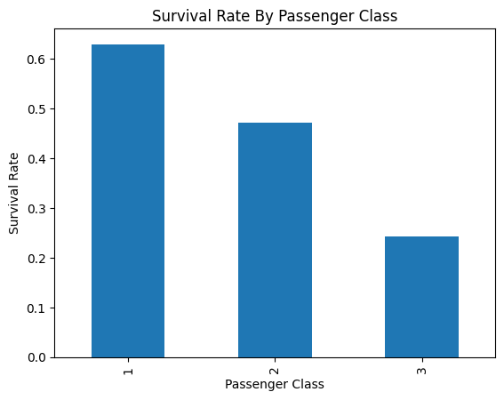

```python
data.groupby("Pclass")["Survived"].mean().plot(kind="bar")
plt.title("Survival Rate By Passenger Class")
plt.xlabel("Passenger Class")
plt.ylabel("Survival Rate")
plt.show()
```

Here we can see the distribution of survivors based on social class. As you can see, the lower the class, the lower the survivor rate is. This would make sense for the time period that the accident took place. Similar to the policy that the previous question follows, there most likely was a rule set in place that said that in an emergency, the people that were part of the higher classes would evacuate first. So in conclusion, I can confidently say that the passenger class did effect the survival rate.

5. Was there a relationship between fare price and survival?

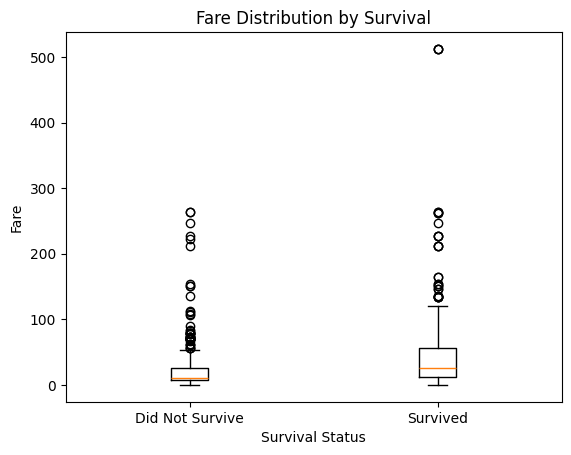

```python
survived_fare = data[data["Survived"] == 1]["Fare"]
not_survived_fare = data[data["Survived"] == 0]["Fare"]
plt.boxplot([not_survived_fare, survived_fare], tick_labels=["Did Not Survive", "Survived"])
plt.title("Fare Distribution by Survival")
plt.xlabel("Survival Status")
plt.ylabel("Fare")
plt.show()
```

For this question, I decided to use two box plots to help visualize the data. This helps us show the difference between the distribution that survived and the distribution that didn't. From this graphic, we can see that the fare amounts of the people who survived were much higher than those that didn't. It's even more interesting that the survived distribution has such a high outlier, which after researching, I learned was because the occupant was living in a luxury suite, which is over 100,000 dollars in today's money. All in all, I believe the reason that this distribution is the way it is could be because the people that paid higher fares were part of higher social classes, and we know that higher social classes had a higher survival rate from our other graph. So in conclusion, I can say that there is a relationship between fair price and survival.

6. Did the embarked location matter in survival?

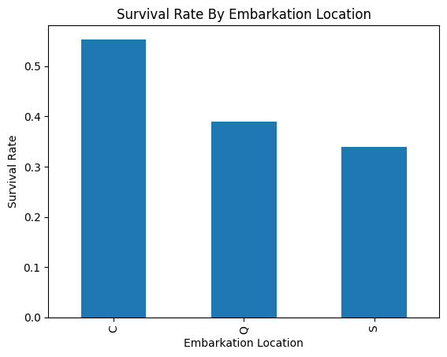

```python
data.groupby("Embarked")["Survived"].mean().plot(kind="bar")
plt.title("Survival Rate By Embarkation Location")
plt.xlabel("Embarkation Location")
plt.ylabel("Survival Rate")
plt.show()
```

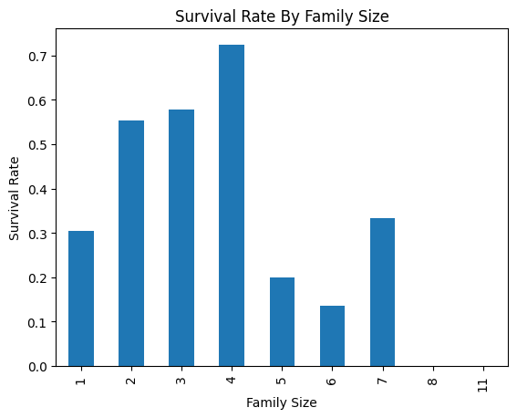

```python
data.groupby("FamilySize")["Survived"].mean().plot(kind="bar")
plt.title("Survival Rate By Family Size")
plt.xlabel("Family Size")
plt.ylabel("Survival Rate")
plt.show()
```

From this final graph, we can see that there tends to be a much higher survival rate for families of four. Although I did my research, this still is unlcear to me why. I believe that the reason is because there were a high amount of four person families comapred to the others, and this can possible influence the data. However, this graph is pretty all over the place, and doesn't really show a relationship. So I would conclude that there is no relationship between the family size and the survival rate.

## Insights Based off of Findings

From the findings we have now made based off the questions that we had, we can now frame a better answer as to what really influenced survival the most during the event. As we can see, we saw relationships between a lot of the graphs that we ended up getting. However, a lot of these findings were also influence by the historical time period in which the incident took place, and the way that they decided to react to the situation.

Firstly, we know that there was a pretty obvious relationship between gender and the survival rate, as women had a much higher rate of survival than men. We discussed why this is prevoiusly, as women were often said to evacuate first in the case of an emergency. This is a relationship that can stand by itself and has little indirect relationships with the results of the other graphs.

However, the passenger class, fare, and the location that they embarked from might all be related to one another. As we know from the passenger class, many of the passengers that were part of the higher classes had a higher survival rate, and this makes sense because they were people who, at that time, were seen as people of importance. We can also say that these people were rather wealthy in comparison to the ones that were in the third class.

This shows that the classes also had a role in the fare toll, as people from higher classes are more likely to pay more money for tickets while they are on the ship. The higher ticket could probably be because they wanted to live in a more luxorious suite or a better quality room in general. The room could also be in a more secure part of the ship, which would also lead to more safety when the ship hit the iceberg.

From these conclusions, we can say that gender defintely had a direct relationship with the survival rate when the event occurred. Along with this, the passenger class, the fare amount, and the embarkation location all had a direct relationship as well but for one similar reason: The norms of social status during the time period in which the event took place.

Now, if this event were to happen today, the survival rate would most likely be a lot different. Since there aren't strict social norms put in place regarding peoples safety, the evacuation system would be much different. It is highly unlikely that they would prioritize one group, and instead treat everyone as equal, doing their best to make sure everyone had access to safety equipment. This would lower the amount of casualities massively, and it would make the above factors that we discussed less important.